# 4 Re-weighting to a target population

Author

Janick Weberpals, RPh, PhD

Published

September 10, 2024

This is a reproducible example on how to incorporate population weights to match distributions of a target population in multiple imputation > matching/weighting > balance assessment > outcome analysis workflows.

Load packages:

```r
library(here)
library(dplyr)
library(survival)
library(mice)
library(MatchThem)
library(MatchIt)
library(survey)
library(gtsummary)

# calling functions
source(here::here("functions", "source_encore.io_functions.R"))

# track time
runtime <- tictoc::tic()
```

## 4.1 Data generation

We use the `simulate_flaura()` function to simulate a realistic oncology comparative effectiveness cohort analytic dataset.

```r
# load example dataset with missing observations
data_miss <- simulate_flaura(
  n_total = 3500,
  treat_prevalence = .51,
  seed = 41,
  include_id = FALSE,
  imposeNA = TRUE
  ) |>
  # we have to convert sex and ecog into a factor variable
  # since anesrake doesn't accept 0/1 numeric encoding for
  # binary variables
  mutate(across(c(dem_sex_cont, c_ecog_cont), function(x) factor(as.character(x))))

covariates <- data_miss |>
  select(starts_with("dem_"), starts_with("c_")) |>
  colnames()
```

## 4.2 Multiple imputation

Multiple imputation using `mice:`

```r
# impute data
data_imp <- futuremice(
  parallelseed = 42,
  n.core = 7,
  data = data_miss,
  method = "rf",
  m = 10,
  print = FALSE
  )
```

## 4.3 Defining target distributions

Before applying the re-weighting, we need to define the target distributions of patient characteristics that we want to match from the clinical trial using the *raking* procedure. The following distributions are taken from Table 1 of the FLAURA trial.

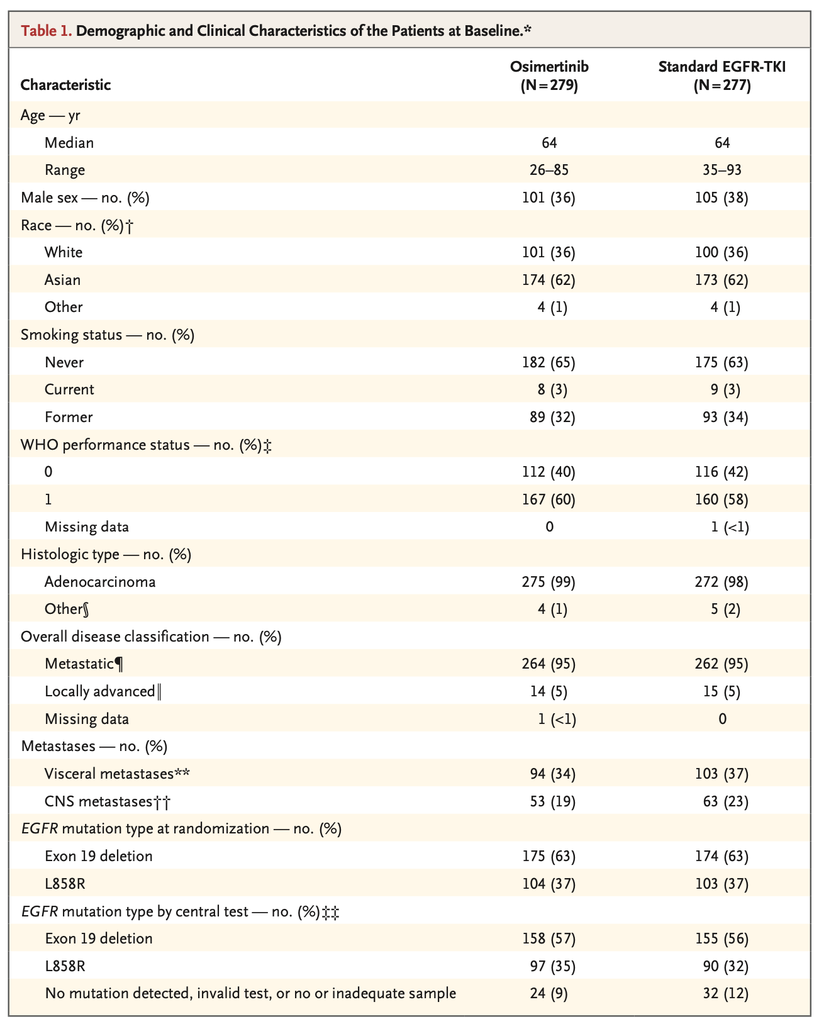

FLAURA trial Table 1; in OS analysis race was simplified to Asian vs. non-Asian

```r
# Define FLAURA distributions for key covariates --------------------------
# order is as in Table 1

## sex ---------------------------------------------------------------------

# female (0) to male (1) proportion:
sex_target <- c(.63, .37)
names(sex_target) <- c("0", "1")

## race --------------------------------------------------------------------
# asian, non-asian
# asian (TRUE) to non-asian (FALSE) proportion
# note: logical variables in dataframe can be matched to a numeric vector of length 2 and ordered with the TRUE target as the first element and the FALSE target as the second element.
race_target <- c(.62, .38)

## smoking -----------------------------------------------------------------

# current/former smoker (TRUE) to never smoker (FALSE) proportion
# note: logical variables in dataframe can be matched to a numeric vector of length 2 and ordered with the TRUE target as the first element and the FALSE target as the second element.
smoker_target <- c(.35, .65)

## ecog --------------------------------------------------------------------

# ecog 0 by exposure
avg_prop_ecog0 <- .41

# ecog 0 to ecog 1 proportion
ecog_target <- c(.41, .59)
names(ecog_target) <- c("0", "1")


# summarize target distributions in a named list vector --------------
targets <- list(sex_target, race_target, smoker_target, ecog_target)
names(targets) <- c("dem_sex_cont", "dem_race", "c_smoking_history", "c_ecog_cont")

# print
targets
```

```
$dem_sex_cont
   0    1
0.63 0.37

$dem_race
[1] 0.62 0.38

$c_smoking_history
[1] 0.35 0.65

$c_ecog_cont
   0    1
0.41 0.59
```

## 4.4 Propensity score matching and re-weighting

In this step, propensity score matching and re-weighting of key patient characteristics to match those of the original RCT is performed across all imputed datasets.

The propensity score model is specified as follows:

```r
# apply propensity score matching on mids object
ps_form <- as.formula(paste("treat ~", paste(covariates, collapse = " + ")))
ps_form
```

```
treat ~ dem_age_index_cont + dem_sex_cont + dem_race + dem_region +
    dem_ses + c_smoking_history + c_number_met_sites + c_ecog_cont +
    c_stage_initial_dx_cont + c_hemoglobin_g_dl_cont + c_urea_nitrogen_mg_dl_cont +
    c_platelets_10_9_l_cont + c_calcium_mg_dl_cont + c_glucose_mg_dl_cont +
    c_lymphocyte_leukocyte_ratio_cont + c_alp_u_l_cont + c_protein_g_l_cont +
    c_alt_u_l_cont + c_albumin_g_l_cont + c_bilirubin_mg_dl_cont +
    c_chloride_mmol_l_cont + c_monocytes_10_9_l_cont + c_eosinophils_leukocytes_ratio_cont +
    c_ldh_u_l_cont + c_hr_cont + c_sbp_cont + c_oxygen_cont +
    c_neutrophil_lymphocyte_ratio_cont + c_bmi_cont + c_ast_alt_ratio_cont +
    c_time_dx_to_index + c_de_novo_mets_dx + c_height_cont +
    c_weight_cont + c_dbp_cont + c_year_index
```

The matching and re-weighting is performed using the `re_weight()` function. This function is a wrapper for `matchit()` and `weightit()` in combination with the `anesrake()` function which performs the *raking* (= re-weighting) procedure.

We apply this function to each imputed dataset. Before doing so, the imputed datasets, which are currently stored as a `mids` object, needs to be converted to a list of dataframes:

```r
# create a mild object containing lists of data.frames
data_mild <- mice::complete(data = data_imp, action = "all", include = FALSE)

summary(data_mild)
```

```
   Length Class      Mode
1  39     data.frame list
2  39     data.frame list
3  39     data.frame list
4  39     data.frame list
5  39     data.frame list
6  39     data.frame list
7  39     data.frame list
8  39     data.frame list
9  39     data.frame list
10 39     data.frame list
```

The lapply function loops the function through each dataframe and returns a list of `matchit` objects which contain imputed > matched > re-weighted datasets. To take advantage of the features that come with the `cobalt` and `matchthem` packages, the function stores the raking weights as sampling weights (`s.weights`).

```r
# call match re-weight
matchit_out_list <- lapply(
  # list of dataframes
  X = data_mild,
  # call function
  FUN = re_weight,
  # target distributions
  targets = targets,
  # should matching or weighting be performed
  matching_weighting = "matching",
  # matching arguments passed on to matchit() function
  formula = ps_form,
  ratio = 1,
  method = "nearest",
  distance = "glm",
  link = "linear.logit",
  caliper = 0.05,
  replace = F
  )
```

[output not shown]

We can inspect the output of the first imputed > matched > re-weighted dataset.

```r
matchit_out_list[[1]]
```

```
A matchit object
 - method: 1:1 nearest neighbor matching without replacement
 - distance: Propensity score [caliper]
             - estimated with logistic regression and linearized
             - sampling weights not included in estimation
 - caliper: <distance> (0.179)
 - number of obs.: 3500 (original), 366 (matched)
 - sampling weights: present
 - target estimand: ATT
 - covariates: dem_age_index_cont, dem_sex_cont, dem_race, dem_region, dem_ses, c_smoking_history, c_number_met_sites, c_ecog_cont, c_stage_initial_dx_cont, c_hemoglobin_g_dl_cont, c_urea_nitrogen_mg_dl_cont, c_platelets_10_9_l_cont, c_calcium_mg_dl_cont, c_glucose_mg_dl_cont, c_lymphocyte_leukocyte…
```

## 4.5 Table 1

To check if the re-weighting process worked, we can extract the matched patients and compare a Table 1 that does not include the weights vs. a Table that considers the weights. For this example, we look at the first imputed > matched > re-weighted dataset.

```r
# extract the matched of
first_dataset <- get_matches(
  object = matchit_out_list[[1]]
  )
```

> Reminder : The target distributions look like this

```r
targets
```

```
$dem_sex_cont
   0    1
0.63 0.37

$dem_race
[1] 0.62 0.38

$c_smoking_history
[1] 0.35 0.65

$c_ecog_cont
   0    1
0.41 0.59
```

**Unweighted Table 1**

```r
library(cardx)
library(smd)

# print
first_dataset |>
  tbl_summary(
    by = treat,
    include = names(targets)
    ) |>
  add_difference(test = dplyr::everything() ~ "smd") |>
  add_overall() |>
  modify_column_hide(columns = "conf.low") |>
  modify_header(
    label ~ "**Patient characteristic**",
    stat_0 ~ "**Total** <br> N = {round(N, 2)}",
    stat_1 ~ "**{level}** <br> N = {round(n, 2)} <br> ({style_percent(p, digits=1)}%)",
    stat_2 ~ "**{level}** <br> N = {round(n, 2)} <br> ({style_percent(p, digits=1)}%)"
    ) |>
  modify_spanning_header(c("stat_1", "stat_2") ~ "**Treatment received**")
```

Table 4.1: Table 1 BEFORE re-weighting

| **Patient characteristic** | **Total** N = 366 <sup>1</sup> | **Treatment received** **0** N = 183 (50.0%) <sup>1</sup> | **Treatment received** **1** N = 183 (50.0%) <sup>1</sup> | **Difference** <sup>2</sup> |  |
| --- | --- | --- | --- | --- | --- |
| dem_sex_cont |  |  |  |  | 0.06 |
| 0 | 247 (67%) | 121 (66%) | 126 (69%) |  |  |
| 1 | 119 (33%) | 62 (34%) | 57 (31%) |  |  |
| dem_race | 217 (59%) | 105 (57%) | 112 (61%) | -0.08 |  |
| c_smoking_history | 179 (49%) | 91 (50%) | 88 (48%) | 0.03 |  |
| c_ecog_cont |  |  |  | 0.15 |  |
| 0 | 160 (44%) | 73 (40%) | 87 (48%) |  |  |
| 1 | 206 (56%) | 110 (60%) | 96 (52%) |  |  |

<sup>1</sup> n (%)  
<sup>2</sup> Standardized Mean Difference

**Weighted Table 1**

```r
# create survey object
data_svy <- svydesign(ids = ~ 1, weights = ~ weights, data = first_dataset)

# print
data_svy |>
  tbl_svysummary(
    by = treat,
    include = names(targets)
    ) |>
  add_difference(test = dplyr::everything() ~ "smd") |>
  add_overall() |>
  modify_column_hide(columns = "conf.low") |>
  modify_header(
    label ~ "**Patient characteristic**",
    stat_0 ~ "**Total** <br> N = {round(N, 2)}",
    stat_1 ~ "**{level}** <br> N = {round(n, 2)} <br> ({style_percent(p, digits=1)}%)",
    stat_2 ~ "**{level}** <br> N = {round(n, 2)} <br> ({style_percent(p, digits=1)}%)"
    ) |>
  modify_spanning_header(c("stat_1", "stat_2") ~ "**Treatment received**")
```

Table 4.2: Table 1 AFTER re-weighting

| **Patient characteristic** | **Total** N = 366 <sup>1</sup> | **Treatment received** **0** N = 182.18 (49.8%) <sup>1</sup> | **Treatment received** **1** N = 183.82 (50.2%) <sup>1</sup> | **Difference** <sup>2</sup> |  |
| --- | --- | --- | --- | --- | --- |
| dem_sex_cont |  |  |  |  | 0.04 |
| 0 | 231 (63%) | 113 (62%) | 117 (64%) |  |  |
| 1 | 135 (37%) | 69 (38%) | 66 (36%) |  |  |
| dem_race | 227 (62%) | 110 (61%) | 117 (63%) | -0.06 |  |
| c_smoking_history | 128 (35%) | 66 (36%) | 62 (34%) | 0.05 |  |
| c_ecog_cont |  |  |  | 0.07 |  |
| 0 | 150 (41%) | 72 (39%) | 78 (43%) |  |  |
| 1 | 216 (59%) | 111 (61%) | 105 (57%) |  |  |

<sup>1</sup> n (%)  
<sup>2</sup> Standardized Mean Difference

### 4.5.1 Comparison of custom function vs. `matchthem()`

Lastly, we want to make sure that our custom function results in the same matched datasets as the `matchthem()` function which we use in the main analysis - not considering the re-weighting.

For this demonstration, we use the same matching parameters, but without re-weighting after matching in our custom function.

### 4.5.2 Custom function

We run again our custom function but with `targets = NULL` to not re-weight any of the included covariates. To convert the returned output of a list of matchit objects into an object of type `mimids` we use the `MatchThem::as.mimids()` function.

```r
# call match re-weight
set.seed(42)
matchit_out_list <- lapply(
  X = data_mild,
  FUN = re_weight,
  targets = NULL,
  matching_weighting = "matching",
  formula = ps_form,
  ratio = 1,
  method = "nearest",
  distance = "glm",
  link = "logit",
  caliper = 0.05,
  replace = F
  )
```

```
No target distributions specified, no re-weighting will be performed.
No target distributions specified, no re-weighting will be performed.
No target distributions specified, no re-weighting will be performed.
No target distributions specified, no re-weighting will be performed.
No target distributions specified, no re-weighting will be performed.
No target distributions specified, no re-weighting will be performed.
No target distributions specified, no re-weighting will be performed.
No target distributions specified, no re-weighting will be performed.
No target distributions specified, no re-weighting will be performed.
No target distributions specified, no re-weighting will be performed.
```

```r
# convert the output into a mimids object
data_mimids_from_function <- MatchThem::as.mimids(
  x = matchit_out_list,
  datasets = data_imp
  )

data_mimids_from_function
```

```
Printing               | dataset: #1
```

```
A matchit object
 - method: 1:1 nearest neighbor matching without replacement
 - distance: Propensity score [caliper]
             - estimated with logistic regression
 - caliper: <distance> (0.023)
 - number of obs.: 3500 (original), 364 (matched)
 - target estimand: ATT
 - covariates: dem_age_index_cont, dem_sex_cont, dem_race, dem_region, dem_ses, c_smoking_history, c_number_met_sites, c_ecog_cont, c_stage_initial_dx_cont, c_hemoglobin_g_dl_cont, c_urea_nitrogen_mg_dl_cont, c_platelets_10_9_l_cont, c_calcium_mg_dl_cont, c_glucose_mg_dl_cont, c_lymphocyte_leukocyte…
```

### 4.5.3 `matchthem()` function

The following code resembles the code we would use in the main analysis by implementing the generic `matchthem()` function.

```r
# matching
set.seed(42)
data_mimids <- matchthem(
  datasets = data_imp,
  formula = ps_form,
  ratio = 1,
  method = "nearest",
  distance = "glm",
  link = "logit",
  caliper = 0.05,
  replace = F
  )
```

```
Matching Observations  | dataset: #1 #2 #3 #4 #5 #6 #7 #8 #9 #10
```

```r
data_mimids
```

```
Printing               | dataset: #1
```

```
A matchit object
 - method: 1:1 nearest neighbor matching without replacement
 - distance: Propensity score [caliper]
             - estimated with logistic regression
 - caliper: <distance> (0.023)
 - number of obs.: 3500 (original), 364 (matched)
 - target estimand: ATT
 - covariates: dem_age_index_cont, dem_sex_cont, dem_race, dem_region, dem_ses, c_smoking_history, c_number_met_sites, c_ecog_cont, c_stage_initial_dx_cont, c_hemoglobin_g_dl_cont, c_urea_nitrogen_mg_dl_cont, c_platelets_10_9_l_cont, c_calcium_mg_dl_cont, c_glucose_mg_dl_cont, c_lymphocyte_leukocyte…
```

### 4.5.4 Comparison of stacked datasets

```r
waldo::compare(
  MatchThem::complete(data_mimids_from_function),
  MatchThem::complete(data_mimids)
  )
```

```
✔ No differences
```

## 4.6 Session info

Script runtime: 0.41 minutes.

**Loaded packages**

```r
pander::pander(subset(data.frame(sessioninfo::package_info()), attached==TRUE, c(package, loadedversion)))
```

|  | package | loadedversion |
| --- | --- | --- |
| **cardx** | cardx | 0.2.0 |
| **dplyr** | dplyr | 1.1.4 |
| **gtsummary** | gtsummary | 2.0.1 |
| **here** | here | 1.0.1 |
| **MatchIt** | MatchIt | 4.5.5 |
| **MatchThem** | MatchThem | 1.2.1 |
| **Matrix** | Matrix | 1.7-0 |
| **mice** | mice | 3.16.0 |
| **smd** | smd | 0.7.0 |
| **survey** | survey | 4.4-2 |
| **survival** | survival | 3.5-8 |

**Session info**

**R version 4.4.0 (2024-04-24)**

**Platform:** aarch64-apple-darwin20

**locale:** en_US.UTF-8||en_US.UTF-8||en_US.UTF-8||C||en_US.UTF-8||en_US.UTF-8

**attached base packages:** *grid*, *stats*, *graphics*, *grDevices*, *datasets*, *utils*, *methods* and *base*

**other attached packages:** *smd(v.0.7.0)*, *cardx(v.0.2.0)*, *gtsummary(v.2.0.1)*, *survey(v.4.4-2)*, *Matrix(v.1.7-0)*, *MatchIt(v.4.5.5)*, *MatchThem(v.1.2.1)*, *mice(v.3.16.0)*, *survival(v.3.5-8)*, *dplyr(v.1.1.4)* and *here(v.1.0.1)*

**loaded via a namespace (and not attached):** *tidyselect(v.1.2.1)*, *fastmap(v.1.2.0)*, *digest(v.0.6.37)*, *rpart(v.4.1.23)*, *lifecycle(v.1.0.4)*, *cluster(v.2.1.6)*, *waldo(v.0.5.3)*, *gdata(v.3.0.0)*, *magrittr(v.2.0.3)*, *compiler(v.4.4.0)*, *sass(v.0.4.9)*, *rlang(v.1.1.4)*, *Hmisc(v.5.1-3)*, *tools(v.4.4.0)*, *gt(v.0.11.0)*, *utf8(v.1.2.4)*, *yaml(v.2.3.10)*, *data.table(v.1.16.0)*, *knitr(v.1.48)*, *htmlwidgets(v.1.6.4)*, *xml2(v.1.3.6)*, *withr(v.3.0.1)*, *foreign(v.0.8-86)*, *purrr(v.1.0.2)*, *nnet(v.7.3-19)*, *fansi(v.1.0.6)*, *jomo(v.2.7-6)*, *colorspace(v.2.1-1)*, *future(v.1.34.0)*, *ggplot2(v.3.5.1)*, *gtools(v.3.9.5)*, *globals(v.0.16.3)*, *scales(v.1.3.0)*, *iterators(v.1.0.14)*, *MASS(v.7.3-60.2)*, *cli(v.3.6.3)*, *rmarkdown(v.2.28)*, *crayon(v.1.5.3)*, *generics(v.0.1.3)*, *rstudioapi(v.0.16.0)*, *sessioninfo(v.1.2.2)*, *commonmark(v.1.9.1)*, *minqa(v.1.2.8)*, *DBI(v.1.2.3)*, *pander(v.0.6.5)*, *stringr(v.1.5.1)*, *splines(v.4.4.0)*, *assertthat(v.0.2.1)*, *parallel(v.4.4.0)*, *base64enc(v.0.1-3)*, *mitools(v.2.4)*, *vctrs(v.0.6.5)*, *WeightIt(v.1.3.0)*, *boot(v.1.3-30)*, *glmnet(v.4.1-8)*, *jsonlite(v.1.8.8)*, *mitml(v.0.4-5)*, *Formula(v.1.2-5)*, *htmlTable(v.2.4.3)*, *listenv(v.0.9.1)*, *weights(v.1.0.4)*, *foreach(v.1.5.2)*, *tidyr(v.1.3.1)*, *glue(v.1.7.0)*, *parallelly(v.1.38.0)*, *nloptr(v.2.1.1)*, *pan(v.1.9)*, *chk(v.0.9.2)*, *codetools(v.0.2-20)*, *stringi(v.1.8.4)*, *shape(v.1.4.6.1)*, *gtable(v.0.3.5)*, *lme4(v.1.1-35.5)*, *munsell(v.0.5.1)*, *tibble(v.3.2.1)*, *anesrake(v.0.80)*, *pillar(v.1.9.0)*, *furrr(v.0.3.1)*, *htmltools(v.0.5.8.1)*, *R6(v.2.5.1)*, *rprojroot(v.2.0.4)*, *evaluate(v.0.24.0)*, *lattice(v.0.22-6)*, *markdown(v.1.13)*, *cards(v.0.2.1)*, *backports(v.1.5.0)*, *tictoc(v.1.2.1)*, *broom(v.1.0.6)*, *renv(v.1.0.7)*, *simsurv(v.1.0.0)*, *Rcpp(v.1.0.13)*, *gridExtra(v.2.3)*, *nlme(v.3.1-164)*, *checkmate(v.2.3.2)*, *xfun(v.0.47)* and *pkgconfig(v.2.0.3)*

**Repositories**

```r
pander::pander(options('repos'))
```

- **repos**:

  | REPO_NAME |
  | --- |
  | https://packagemanager.posit.co/cran/latest |